# Remote Sensing | Free Full-Text | The Transferability of Random Forest in Canopy Height Estimation from Multi-Source Remote Sensing Data

Remote Sensing

[Journals](https://www.mdpi.com/about/journals)

[Remote Sensing](https://www.mdpi.com/journal/remotesensing)

[Volume 10](https://www.mdpi.com/2072-4292/10)

[Issue 8](https://www.mdpi.com/2072-4292/10/8)

10.3390/rs10081183

[figure not shown]

## Article Menu

Citations 9

[figure not shown]

[figure not shown]

0

*textsms*

0

Open AccessArticle

# The Transferability of Random Forest in Canopy Height Estimation from Multi-Source Remote Sensing Data

by

Shichao Jin

<sup>1,2,†</sup>,

Yanjun Su

<sup>1,2,3,†</sup>,

Shang Gao

<sup>1,2</sup>,

Tianyu Hu

<sup>1</sup>,

Jin Liu

<sup>1</sup> and

Qinghua Guo

<sup>1,2,3,*</sup>

<sup>1</sup>

State Key Laboratory of Vegetation and Environmental Change, Institute of Botany, Chinese Academy of Sciences, Beijing 100093, China

<sup>2</sup>

University of Chinese Academy of Sciences, No. 19A Yuquan Road, Beijing 100049, China

<sup>3</sup>

Sierra Nevada Research Institute, School of Engineering, University of California Merced, Merced, CA 95343, USA

Author to whom correspondence should be addressed.

†

These authors contributed equally to this work.

*Remote Sens.* **2018**, *10*(8), 1183; https://doi.org/10.3390/rs10081183

Received: 15 May 2018 / Revised: 4 July 2018 / Accepted: 24 July 2018 / Published: 26 July 2018

(This article belongs to the Section [Forest Remote Sensing](https://www.mdpi.com/journal/remotesensing/sections/Forest_Remote_Sensing))

[View Full-Text](https://www.mdpi.com/2072-4292/10/8/1183/htm) [Download PDF](https://www.mdpi.com/2072-4292/10/8/1183/pdf)

## Abstract

Canopy height is an important forest structure parameter for understanding forest ecosystem and improving global carbon stock quantification accuracy. Light detection and ranging (LiDAR) can provide accurate canopy height measurements, but its application at large scales is limited. Using LiDAR-derived canopy height as ground truth to train the Random Forest (RF) algorithm and therefore predict canopy height from other remotely sensed datasets in areas without LiDAR coverage has been one of the most commonly used method in large-scale canopy height mapping. However, how variances in location, vegetation type, and spatial scale of study sites influence the RF modelling results is still a question that needs to be addressed. In this study, we selected 16 study sites (100 km<sup>2</sup> each) with full airborne LiDAR coverage across the United States, and used the LiDAR-derived canopy height along with optical imagery, topographic data, and climate surfaces to evaluate the transferability of the RF-based canopy height prediction method. The results show a series of findings from general to complex. The RF model trained at a certain location or vegetation type cannot be transferred to other locations or vegetation types. However, by training the RF algorithm using samples from all sites with various vegetation types, a universal model can be achieved for predicting canopy height at different locations and different vegetation types with self-predicted R<sup>2</sup> higher than 0.6 and RMSE lower than 6 m. Moreover, the influence of spatial scales on the RF prediction accuracy is noticeable when spatial extent of the study site is less than 50 km<sup>2</sup> or the spatial resolution of the training pixel is finer than 500 m. The canopy height prediction accuracy increases with the spatial extent and the targeted spatial resolution. [View Full-Text](https://www.mdpi.com/2072-4292/10/8/1183/htm)

*Keywords:* [canopy height](https://www.mdpi.com/search?q=canopy%20height); [Random Forest](https://www.mdpi.com/search?q=Random%20Forest); LiDAR; multi-source; [vegetation type](https://www.mdpi.com/search?q=vegetation%20type); location; scale

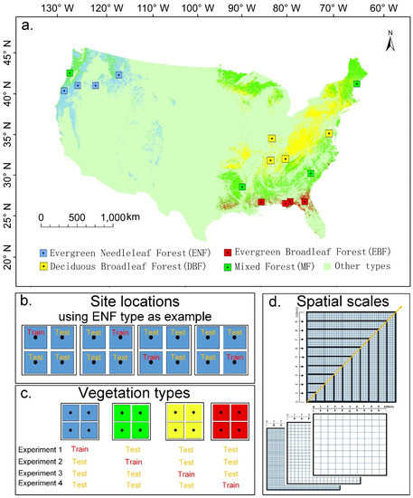

This is an open access article distributed under the [Creative Commons Attribution License](https://creativecommons.org/licenses/by/4.0/) which permits unrestricted use, distribution, and reproduction in any medium, provided the original work is properly cited

[figure not shown]

## Share and Cite

**MDPI and ACS Style**

**AMA Style**

**Chicago/Turabian Style**

**Find Other Styles**

## Article Metrics

### Citations

Crossref

9

Web of Science

7

Scopus

ads

[5](https://ui.adsabs.harvard.edu/#abs/2018RemS...10.1183J/citations)

Google Scholar

[click to view]

### Article Access Statistics

[figure not shown]

For more information on the journal statistics, click [here](https://www.mdpi.com/journal/remotesensing/stats).

## Related Articles

   Xiliang Ni, Remote Sens, 2015
2. [Mapping Vegetation at Species Level With High-Resolution Multispectral And Lidar Data Over A Large Spatial Area: A Case Study With Kudzu](https://www.mdpi.com/2072-4292/12/4/609?utm_source=TrendMD&utm_medium=cpc&utm_campaign=Remote_Sens_TrendMD_0)

   Liang et al., Remote Sens, 2020
3. [Canopy Height Estimation Using Sentinel Series Images through Machine Learning Models in a Mangrove Forest](https://www.mdpi.com/2072-4292/12/9/1519?utm_source=TrendMD&utm_medium=cpc&utm_campaign=Remote_Sens_TrendMD_0)

   Ghosh et al., Remote Sens, 2020
4. [Remote Estimation of Mangrove Aboveground Carbon Stock at the Species Level Using a Low-Cost Unmanned Aerial Vehicle System](https://www.mdpi.com/2072-4292/11/9/1018?utm_source=TrendMD&utm_medium=cpc&utm_campaign=Remote_Sens_TrendMD_0)

   Huichun Ye et al., International Journal of Agricultural and Biological Engineering, 2020
2. Wheat stripe rust monitoring by random forest algorithm combined with SIF and reflectance spectrum

   Jing Xia et al., Transactions of the Chinese Society of Agricultural Engineering, 2018
3. Spatial distribution of soil salinity in Ugan-Kuqa River delta oasis based on environmental variables

[Powered by](https://www.trendmd.com/how-it-works-readers)

**Search more from Scilit**

Search

*[Remote Sens.](https://www.mdpi.com/journal/remotesensing)*, EISSN 2072-4292, Published by MDPI Disclaimer

[RSS](https://www.mdpi.com/rss/journal/remotesensing) [Content Alert](https://www.mdpi.com/journal/remotesensing/toc-alert)

### Follow MDPI

Disclaimer